# e89_alfred_okoronkwo_HW01

```python
import tensorflow as tf
import timeit
```

## Problem 1:

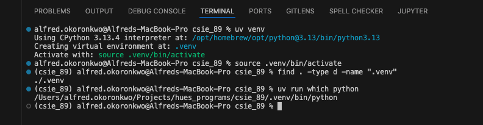

## Problem 2:

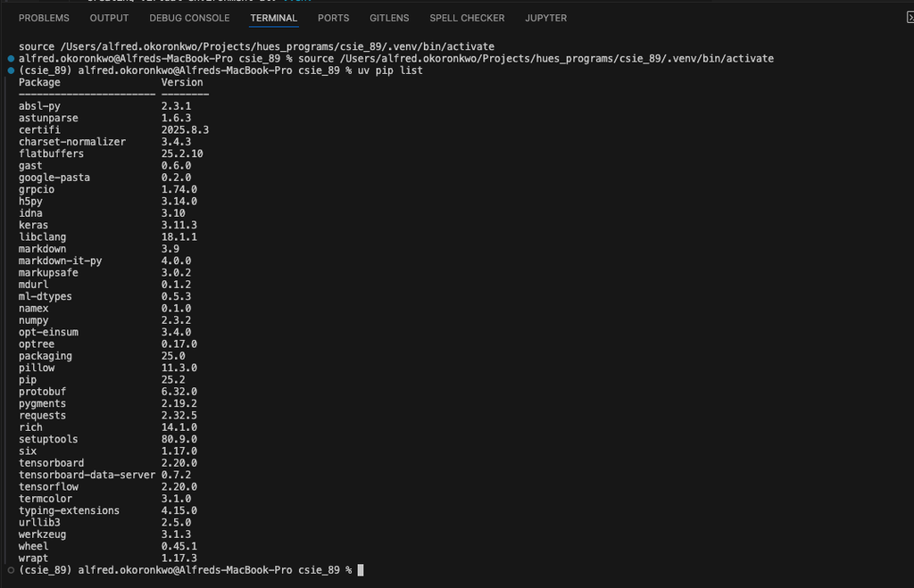

## Problem 3:

```python
tensor1 = tf.constant([[1, 2], [3, 4]])
tensor2 = tf.constant([[10, 20], [30, 40]])
tensor3 = tensor1 + tensor2
tensor4 = tf.add(tensor1, tensor2)
tf.debugging.assert_equal(
    tensor3,
    tensor4,
    message=f"expected tensor3:\n{tensor3.numpy()}\nto be equal to tensor4:\n{tensor4.numpy()}"
)
```

## Problem 4:

```python
dir(timeit)
```

```
['Timer',
 '__all__',
 '__builtins__',
 '__cached__',
 '__doc__',
 '__file__',
 '__loader__',
 '__name__',
 '__package__',
 '__spec__',
 '_globals',
 'default_number',
 'default_repeat',
 'default_timer',
 'dummy_src_name',
 'gc',
 'itertools',
 'main',
 'reindent',
 'repeat',
 'sys',
 'template',
 'time',
 'timeit']
```

## check physical GPU availability

```python
# returns whether TensorFlow was built with CUDA (GPU) support
tf.test.is_built_with_cuda()
```

```
False
```

```python
# returns a list of available physical GPUs
tf.config.list_physical_devices("GPU")
```

```
[]
```

```python
# returns the names of physical GPUs
tf.test.gpu_device_name()
```

```
''
```

## a test case

```python
# initialize random matrices on CPU and GPU
with tf.device("/CPU:0"):
    cpu_m1 = tf.random.normal(shape=[10000, 1000])
    cpu_m2 = tf.random.normal(shape=[1000, 5000])
    print(cpu_m1.device, "\n", cpu_m2.device, "\n"*2)

with tf.device("/GPU:0"):
    gpu_m1 = tf.random.normal([10000, 1000])
    gpu_m2 = tf.random.normal([1000, 5000])
    print(gpu_m1.device, "\n", gpu_m2.device)
```

```
/job:localhost/replica:0/task:0/device:CPU:0
 /job:localhost/replica:0/task:0/device:CPU:0


/job:localhost/replica:0/task:0/device:CPU:0
 /job:localhost/replica:0/task:0/device:CPU:0
```

```python
# perform matrix multiplication test
def cpu_test():
    with tf.device("/CPU:0"):
        res = tf.matmul(cpu_m1, cpu_m2)
    return res

def gpu_test():
    with tf.device("/GPU:0"):
        res = tf.matmul(gpu_m1, gpu_m2)
    return res

if __name__ == "__main__":
    cpu_time = timeit.timeit(cpu_test, number=50)
    gpu_time = timeit.timeit(gpu_test, number=50)
    print(f"CPU run time: {cpu_time}\nGPU run time: {gpu_time}")
```

```
CPU run time: 7.821720583997376
GPU run time: 7.668790541996714
```

## Problem 5:

#### Test result from colab with CPU only

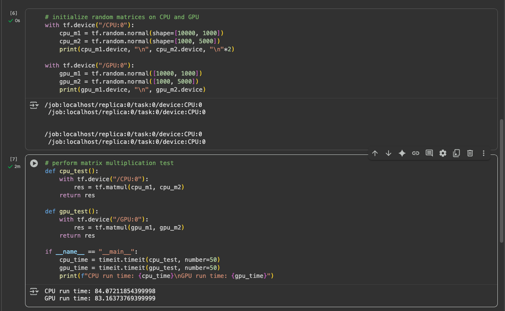

#### Test result from colab with CPU and GPU

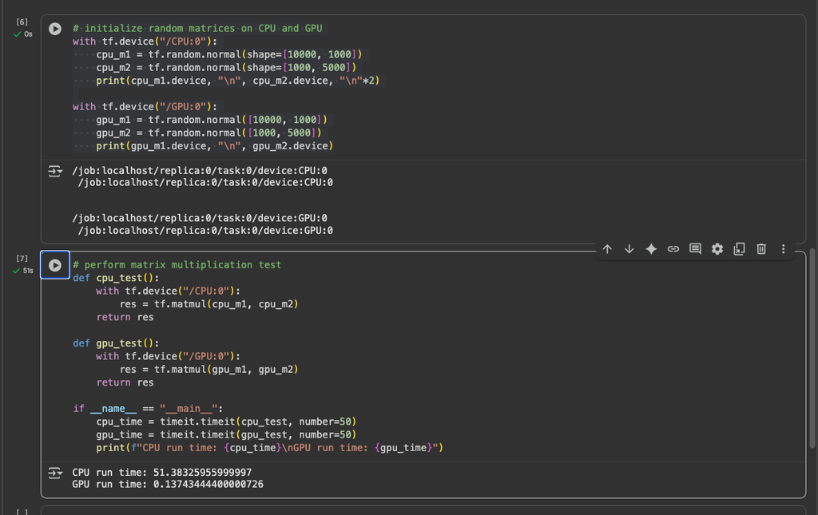

## Problem 6:

```python
print(tf.__version__)
```

```
2.20.0
```

```python
!uv pip install matplotlib
```

```
Using Python 3.13.4 environment at: /Users/alfred.okoronkwo/Projects/hues_programs/csie_89/.venv
Audited 1 package in 17ms
```

```python
# Auxiliary libraries
# Helper libraries
import numpy as np
import matplotlib.pyplot as plt
```

```python
mnist = tf.keras.datasets.mnist

(x_train, y_train), (x_test, y_test) = mnist.load_data()
x_train, x_test = x_train / 255.0, x_test / 255.0
```

```python
print(x_train.shape, y_train.shape)
```

```
(60000, 28, 28) (60000,)
```

```python
y_train
```

```
array([5, 0, 4, ..., 5, 6, 8], shape=(60000,), dtype=uint8)
```

#### Inspect an Image

```
4
```

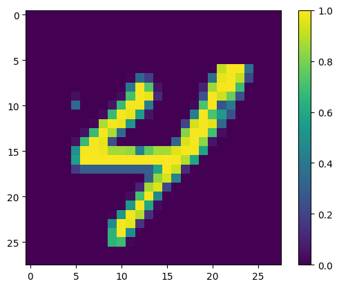

```python
index = 89
print(y_train[index])
plt.figure()
plt.imshow(x_train[index])
plt.colorbar()
plt.grid(False)
plt.show()
```

#### Build a machine learning model

Sequential model is useful for stacking layers where each layer has one input tensor and one output tensor. Layers are functions with a known mathematical structure that can be reused and have trainable variables. Most TensorFlow models are composed of layers. This model uses the Flatten, Dense, and Dropout layers.

```python
model = tf.keras.models.Sequential([
    tf.keras.layers.Input(shape=(28,28)),
    tf.keras.layers.Flatten(),
    tf.keras.layers.Dense(128, activation='relu'),
    tf.keras.layers.Dropout(0.2),
    tf.keras.layers.Dense(10)
])
```

```python
predictions = model(x_train[:1]).numpy()
predictions
```

```
array([[ 0.2111068 ,  0.00450844, -1.0114357 ,  0.07396257,  0.5331006 ,
         0.16794227, -0.4558587 ,  0.38420162,  0.17602056,  0.32485244]],
      dtype=float32)
```

```python
tf.nn.softmax(predictions).numpy()
```

```
array([[0.10982334, 0.08932441, 0.03234083, 0.09574887, 0.15154262,
        0.10518372, 0.05636834, 0.13057764, 0.10603687, 0.12305345]],
      dtype=float32)
```

Define a loss function for training using `losses.SparseCategoricalCrossentropy`:

```python
loss_fn = tf.keras.losses.SparseCategoricalCrossentropy(from_logits=True)
```

The loss function takes a vector of ground truth values and a vector of logits and returns a scalar loss for each example. This loss is equal to the negative log probability of the true class: The loss is zero if the model is sure of the correct class.

This untrained model gives probabilities close to random (1/10 for each class), so the initial loss should be close to `-tf.math.log(1/10) ~= 2.3`.

```python
loss_fn(y_train[:1], predictions).numpy()
```

```
np.float32(2.2520466)
```

Before you start training, configure and compile the model using Keras `Model.compile`. Set the optimizer class to `adam`, set the `loss` to the `loss_fn` function you defined earlier, and specify a `metric` to be evaluated for the `model` by setting the `etrics` parameter to `accuracy`.

```python
model.compile(optimizer='adam', loss=loss_fn, metrics=['accuracy'])
```

#### Train and evaluate your model

Use the `Model.fit` method to adjust your `model` parameters and minimize the `loss`:

```python
model.fit(x_train, y_train, epochs=5)
```

```
1875/1875 ━━━━━━━━━━━━━━━━━━━━ 1s 559us/step - accuracy: 0.9158 - loss: 0.2919
1875/1875 ━━━━━━━━━━━━━━━━━━━━ 1s 546us/step - accuracy: 0.9583 - loss: 0.1413
1875/1875 ━━━━━━━━━━━━━━━━━━━━ 1s 561us/step - accuracy: 0.9677 - loss: 0.1061
1875/1875 ━━━━━━━━━━━━━━━━━━━━ 1s 541us/step - accuracy: 0.9732 - loss: 0.0863
1875/1875 ━━━━━━━━━━━━━━━━━━━━ 1s 549us/step - accuracy: 0.9771 - loss: 0.0736
```

```
<keras.src.callbacks.history.History at 0x14ac8c2f0>
```

The `Model.evaluate` method checks the model's performance, usually on a validation set or test set.

```python
model.evaluate(x_test,  y_test, verbose=2)
```

```
313/313 - 0s - 483us/step - accuracy: 0.9770 - loss: 0.0720
```

```
[0.07204119116067886, 0.9769999980926514]
```

The image classifier is now trained to ~98% accuracy on this dataset.

```python
np.random.seed(42)
random_indices = np.random.choice(x_test.shape[0], size=4, replace=False)
sample_images = x_test[random_indices]
sample_labels = y_test[random_indices]
print(random_indices)
print(sample_labels)
```

```
[6252 4684 1731 4742]
[6 2 3 7]
```

```python
sample_predictions = model.predict(sample_images)
predicted_digits = np.argmax(sample_predictions, axis=1)
```

```
1/1 ━━━━━━━━━━━━━━━━━━━━ 0s 26ms/step
```

```
6
```

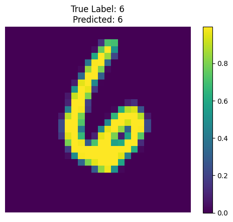

```
2
```

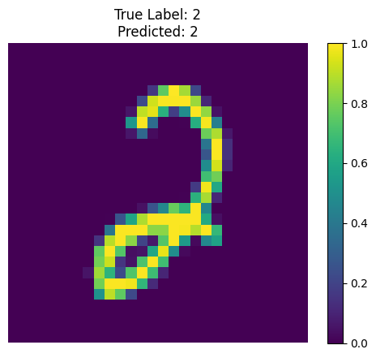

```
3
```

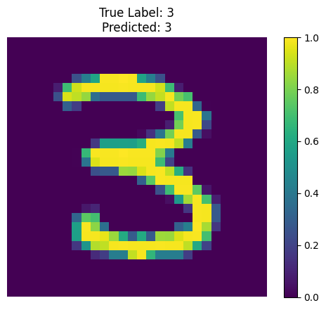

```
7
```

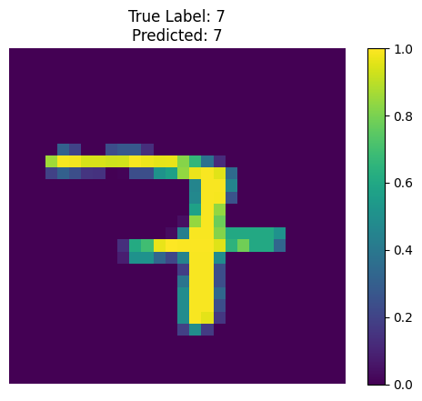

```python
for index in range(4):
    print(sample_labels[index])
    plt.figure()
    plt.imshow(sample_images[index])
    plt.title(f"True Label: {sample_labels[index]}\nPredicted: {predicted_digits[index]}")
    plt.axis('off')
    plt.colorbar()
    plt.grid(False)
    plt.show()
```

## Experiment 2

Create new training sets with 10,000 samples from the original set

```python
x_train_exp2 = x_train[:10000]
y_train_exp2 = y_train[:10000]

print(x_train_exp2.shape, y_train_exp2.shape)
y_train_exp2
```

```
(10000, 28, 28) (10000,)
```

```
array([5, 0, 4, ..., 6, 9, 7], shape=(10000,), dtype=uint8)
```

Inspect an image from the reduced training set

```
3
```

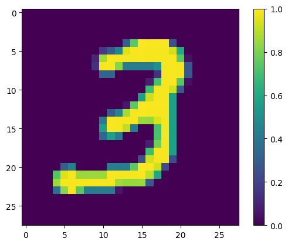

```python
index = 107
print(y_train_exp2[index])
plt.figure()
plt.imshow(x_train_exp2[index])
plt.colorbar()
plt.grid(False)
plt.show()
```

### Build a new machine learning model

```python
model_exp2 = tf.keras.models.Sequential([
    tf.keras.layers.Input(shape=(28, 28)),
    tf.keras.layers.Flatten(),
    tf.keras.layers.Dense(128, activation='relu'),
    tf.keras.layers.Dropout(0.2),
    tf.keras.layers.Dense(10)
])
```

```python
predictions_exp2 = model_exp2(x_train_exp2[:1]).numpy()
predictions_exp2
```

```
array([[-0.6223335 , -0.29939955,  0.55401534, -0.42039475, -0.10893278,
         0.30373818,  0.12445833,  0.0142065 , -0.09847876,  0.04975718]],
      dtype=float32)
```

```python
tf.nn.softmax(predictions_exp2).numpy()
```

```
array([[0.05350455, 0.0738991 , 0.17348923, 0.06547742, 0.08940417,
        0.1350761 , 0.11290632, 0.10111987, 0.09034371, 0.10477941]],
      dtype=float32)
```

```python
loss_fn_exp2 = tf.keras.losses.SparseCategoricalCrossentropy(from_logits=True)
loss_fn_exp2(y_train_exp2[:1], predictions_exp2).numpy()
```

```
np.float32(2.001917)
```

```python
model_exp2.compile(optimizer='adam', loss=loss_fn_exp2, metrics=['accuracy'])
```

### Train and evaluate the model

```python
model_exp2.fit(x_train_exp2, y_train_exp2)
model_exp2.evaluate(x_test, y_test, verbose=2)
```

```
313/313 ━━━━━━━━━━━━━━━━━━━━ 0s 620us/step - accuracy: 0.8312 - loss: 0.5800
313/313 - 0s - 468us/step - accuracy: 0.9101 - loss: 0.3024
```

```
[0.3024156093597412, 0.910099983215332]
```

```python
x_train_exp2_predictions = model_exp2.predict(x_train_exp2)
exp2_predicted_digit = np.argmax(x_train_exp2_predictions, axis=1)
```

```
313/313 ━━━━━━━━━━━━━━━━━━━━ 0s 274us/step
```

The image classifier is now trained to ~91% accuracy on the reduced dataset.

### Print 200 samples of the predictions

```python
# To manage space we will print only a 200 predicted digits
# The format will be (true label, predicted label)

# Print labels and the predicted digits
col_headers = ["(y, p)" for _ in range(10)]
header_line = ["------" for _ in range(10)]
print("y: true label, p: predicted digit")
print()

# Print table headers
print(" | " + " | ".join(col_headers) + " | ")
print(" | " + " | ".join(header_line) + " | ")

# Print pairs of the true labels and corresponding predicted outcomes in the same tabular format
pairs = [f"({y_train_exp2[idx]}, {exp2_predicted_digit[idx]})" for idx in range(200)]
for i in range(0, len(pairs), 10):
    print(" | " + " | ".join(pairs[i:i+10]) + " | ")
```

```
y: true label, p: predicted digit

 | (y, p) | (y, p) | (y, p) | (y, p) | (y, p) | (y, p) | (y, p) | (y, p) | (y, p) | (y, p) |
 | ------ | ------ | ------ | ------ | ------ | ------ | ------ | ------ | ------ | ------ |
 | (5, 5) | (0, 0) | (4, 4) | (1, 1) | (9, 9) | (2, 2) | (1, 1) | (3, 3) | (1, 1) | (4, 4) |
 | (3, 3) | (5, 5) | (3, 3) | (6, 6) | (1, 1) | (7, 7) | (2, 2) | (8, 8) | (6, 6) | (9, 9) |
 | (4, 4) | (0, 0) | (9, 9) | (1, 1) | (1, 2) | (2, 2) | (4, 4) | (3, 3) | (2, 2) | (7, 7) |
 | (3, 3) | (8, 8) | (6, 6) | (9, 9) | (0, 0) | (5, 5) | (6, 6) | (0, 0) | (7, 7) | (6, 6) |
 | (1, 1) | (8, 8) | (7, 7) | (9, 9) | (3, 3) | (9, 9) | (8, 8) | (5, 5) | (9, 5) | (3, 3) |
 | (3, 3) | (0, 0) | (7, 7) | (4, 4) | (9, 9) | (8, 9) | (0, 0) | (9, 9) | (4, 4) | (1, 1) |
 | (4, 4) | (4, 4) | (6, 6) | (0, 0) | (4, 4) | (5, 5) | (6, 6) | (1, 1) | (0, 0) | (0, 0) |
 | (1, 1) | (7, 7) | (1, 1) | (6, 6) | (3, 3) | (0, 0) | (2, 2) | (1, 1) | (1, 1) | (7, 7) |
 | (9, 0) | (0, 0) | (2, 2) | (6, 6) | (7, 7) | (8, 8) | (3, 3) | (9, 9) | (0, 0) | (4, 4) |
 | (6, 6) | (7, 7) | (4, 4) | (6, 6) | (8, 8) | (0, 0) | (7, 7) | (8, 8) | (3, 3) | (1, 1) |
 | (5, 5) | (7, 7) | (1, 1) | (7, 7) | (1, 1) | (1, 1) | (6, 6) | (3, 3) | (0, 0) | (2, 2) |
 | (9, 9) | (3, 3) | (1, 1) | (1, 1) | (0, 0) | (4, 4) | (9, 9) | (2, 2) | (0, 0) | (0, 0) |
 | (2, 7) | (0, 0) | (2, 2) | (7, 7) | (1, 1) | (8, 8) | (6, 6) | (4, 4) | (1, 1) | (6, 6) |
 | (3, 3) | (4, 4) | (5, 3) | (9, 9) | (1, 4) | (3, 3) | (3, 3) | (8, 1) | (5, 5) | (4, 4) |
 | (7, 7) | (7, 7) | (4, 4) | (2, 2) | (8, 8) | (5, 5) | (8, 8) | (6, 6) | (7, 9) | (3, 3) |
 | (4, 4) | (6, 6) | (1, 1) | (9, 9) | (9, 9) | (6, 6) | (0, 0) | (3, 3) | (7, 9) | (2, 2) |
 | (8, 8) | (2, 2) | (9, 9) | (4, 4) | (4, 4) | (6, 6) | (4, 4) | (9, 9) | (7, 7) | (0, 0) |
 | (9, 9) | (2, 2) | (9, 7) | (5, 5) | (1, 1) | (5, 5) | (9, 9) | (1, 1) | (2, 2) | (3, 3) |
 | (2, 1) | (3, 3) | (5, 5) | (9, 9) | (1, 1) | (7, 7) | (6, 6) | (2, 2) | (8, 8) | (2, 2) |
 | (2, 2) | (5, 5) | (0, 0) | (7, 7) | (4, 4) | (9, 9) | (7, 7) | (8, 8) | (3, 3) | (2, 2) |
```

#### Plot samples of the predicted images

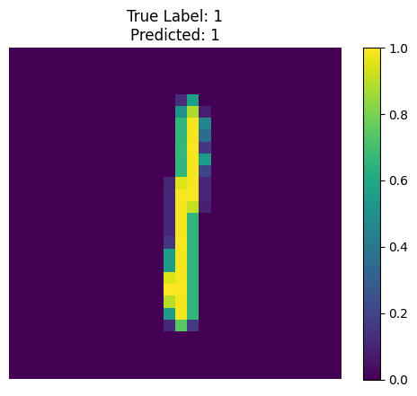

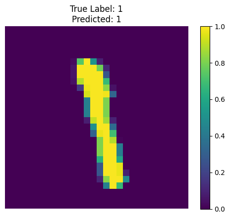

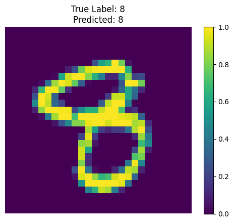

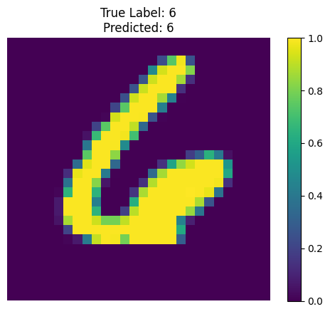

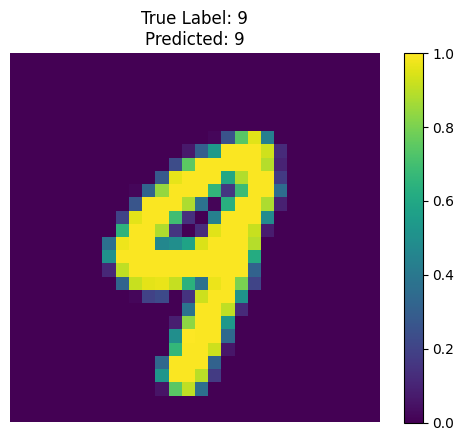

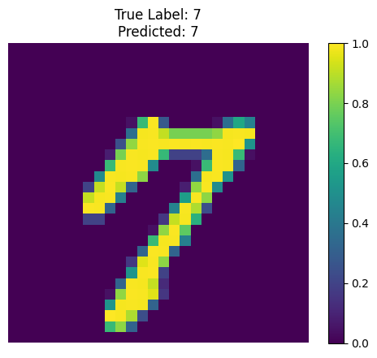

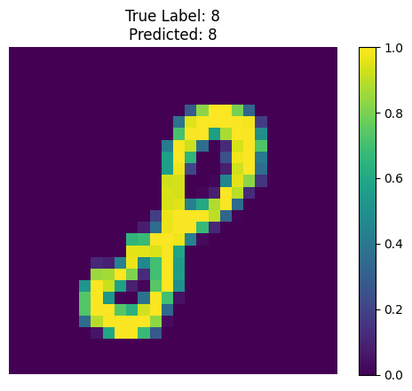

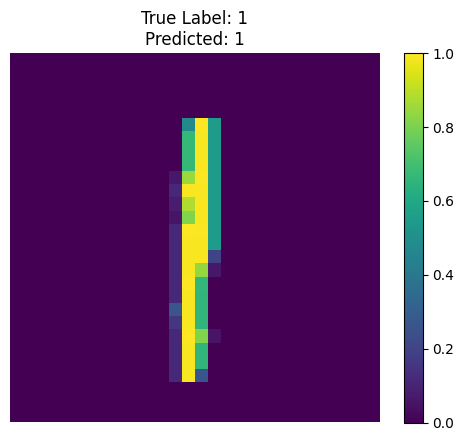

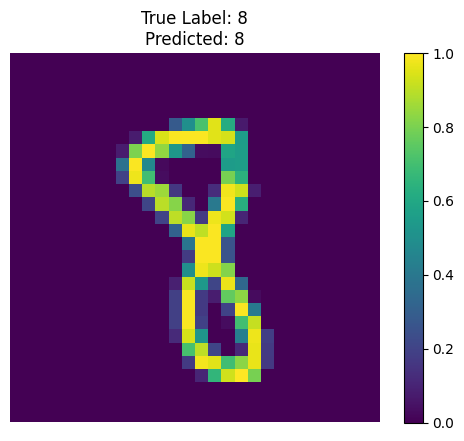

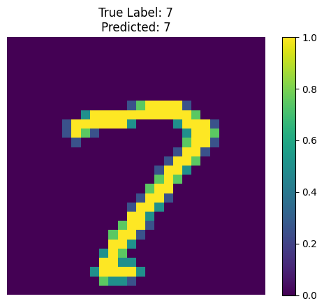

```python
# Print images of 10 random predictions
indexes_print = np.random.choice(x_train_exp2.shape[0], size=10, replace=False)
for index in indexes_print:
    plt.figure()
    plt.imshow(x_train_exp2[index])
    plt.title(f"True Label: {y_train_exp2[index]}\nPredicted: {exp2_predicted_digit[index]}")
    plt.axis("off")
    plt.colorbar()
    plt.grid(False)
    plt.show()
```